# Single-Cell RNA-seq Analysis of Purkinje Cell Development

# 4 Data Integration

## 4.1 Rationale

With samples from different sequencing runs and chemistries (v2 vs v3), technical batch effects could hide biological signal. Integration removes technical variation while preserving biological differences between developmental stages and cell types.

## 4.2 Integration Method: Harmony

```r
library(harmony)

# Standard Seurat workflow
obj <- NormalizeData(obj)
obj <- FindVariableFeatures(obj, selection.method = "vst", nfeatures = 2000)
obj <- ScaleData(obj)
obj <- RunPCA(obj, npcs = 30, verbose = FALSE)

# Run Harmony integration
obj <- RunHarmony(obj,
                  group.by.vars = "orig.ident",
                  dims.use = 1:30,
                  verbose = FALSE)

# UMAP on integrated data
obj <- RunUMAP(obj, reduction = "harmony", dims = 1:30, verbose = FALSE)
```

**Advantages of Harmony**:

- Computationally efficient
- Maintains stage-specific differences while removing technical variation

## 4.3 Integration Results

### 4.3.1 Pre-Integration

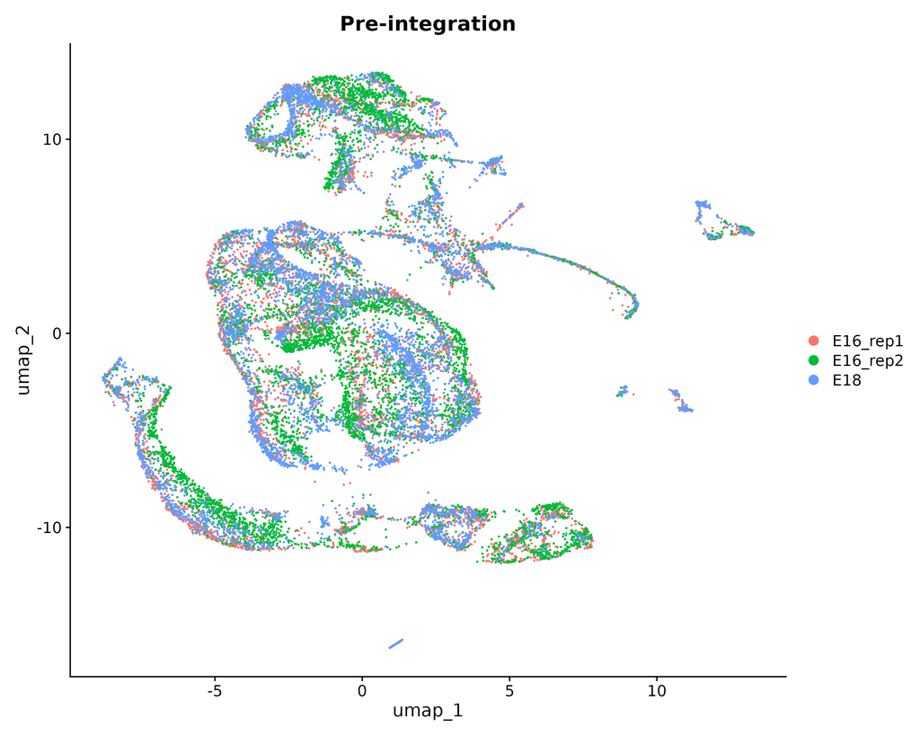

UMAP before integration, colored by sample

### 4.3.2 Post-Integration

**Plot description**: UMAP after Harmony integration. Cells are colored by sample (left) and developmental stage (right). Post-integration, biological replicates mix well while preserving cell type structure and stage-specific biology.

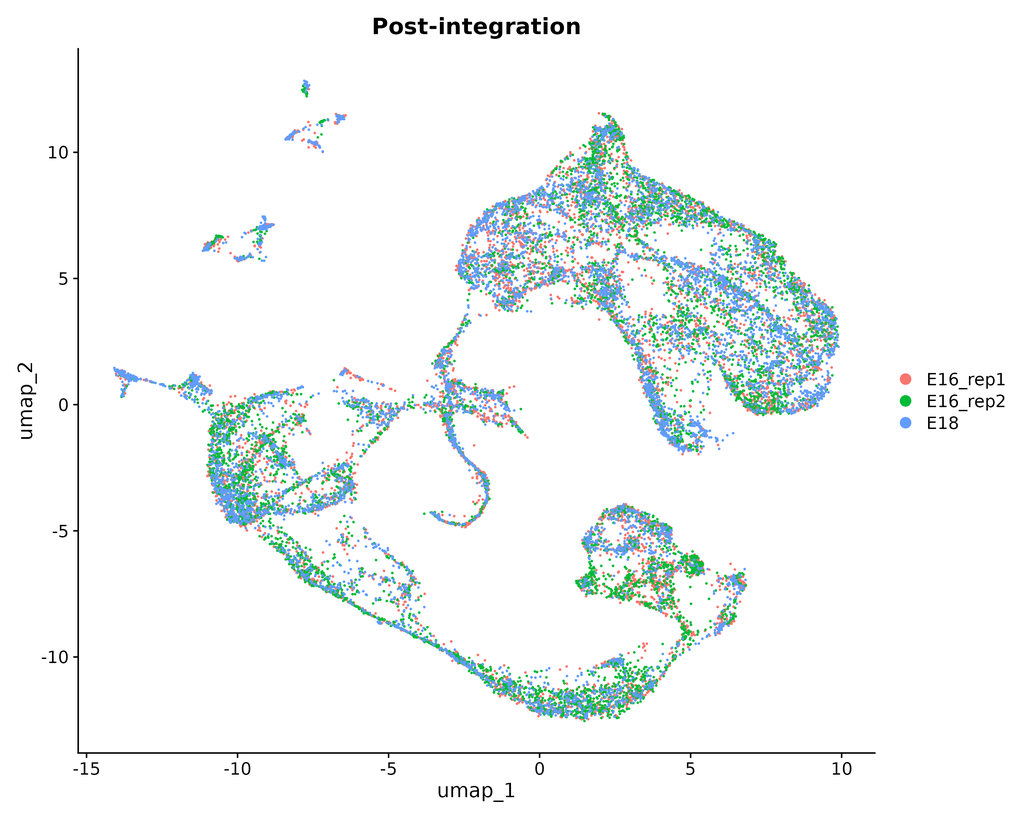

UMAP after integration - by sample

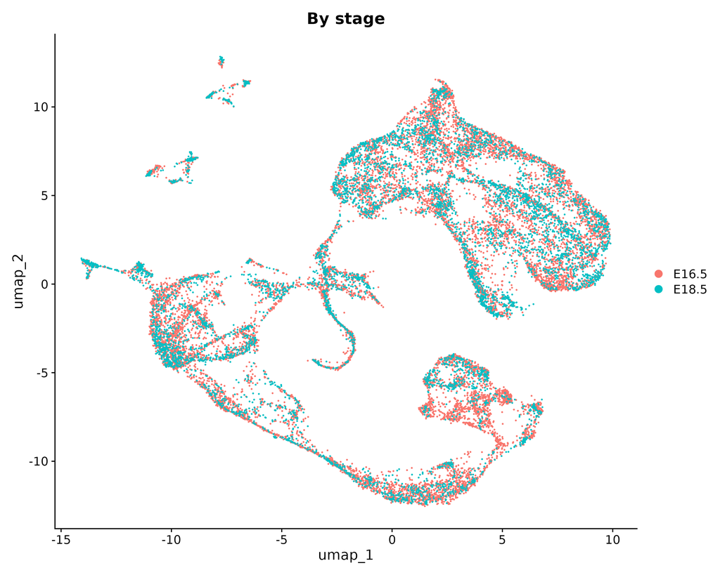

UMAP after integration - by stage

**Observation**: Post-integration, E16.5 biological replicates mix well, confirming successful batch correction. Cell type structure is preserved across samples despite chemistry differences.

# 5 Clustering and Cell Type Annotation

## 5.1 Clustering

```r
# Clustering on Harmony embeddings
obj <- FindNeighbors(obj, reduction = "harmony", dims = 1:30)
obj <- FindClusters(obj, resolution = 0.5, verbose = FALSE)
```

**Resolution selection**: Tested 0.3, 0.5, 0.8. Resolution 0.5 provided optimal balance—higher resolutions over-split known cell types while lower resolutions merged distinct populations.

**Number of clusters identified**: 25 - This is similar to what was published. They found 24 clusters.

## 5.2 Marker Gene Identification

FindAllMarkers identified cluster-specific marker genes by comparing each cluster to all other cells. Only upregulated genes (≥25% expression, log2FC ≥ 0.25) were retained for cell type annotation.

```r
# Find markers for all clusters
markers <- FindAllMarkers(obj,
                          only.pos = TRUE,
                          min.pct = 0.25,
                          logfc.threshold = 0.25,
                          verbose = FALSE)
```

## 5.3 Cell Type Annotation

**Plot description**: UMAP visualization with cells colored by annotated cell type. Each point represents a single cell, positioned based on gene expression similarity (closer = more similar). Annotations are based on canonical marker gene expression for known cerebellar cell types.

Clusters were annotated based on expression of known cerebellar cell type markers:

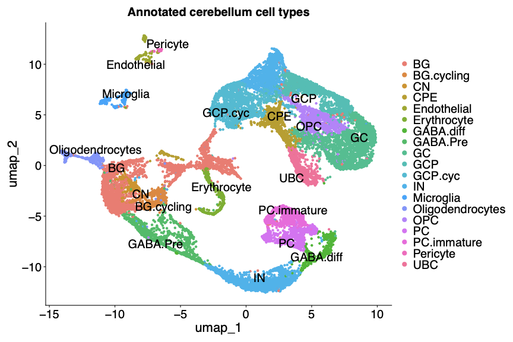

UMAP with annotated cell types

**Major cell types identified**:

[output not shown]

**Purkinje cell validation**: Both PC clusters express Foxp2 (pan-PC marker). Cluster 9 (mature): 98.2% Foxp2+, mean Pcp2 = 1.13. Cluster 11 (immature): 93.6% Foxp2+, mean Pcp2 = 0.25.

# 6 Purkinje Cell Subtyping

## 6.1 Rationale

Following Khouri-Farah et al. (2025), we performed high-resolution clustering on Purkinje cells to identify molecularly distinct PC subtypes. The paper identified 11 subtypes at E16.5-E18.5 using Foxp2 as a pan-PC marker.

## 6.2 Methods

```r
# Subset Purkinje cells
pc_cells <- subset(obj, cell_type %in% c("PC", "PC.immature"))

# Re-cluster at higher resolution
pc_cells <- FindNeighbors(pc_cells, reduction = "harmony", dims = 1:30)
pc_cells <- FindClusters(pc_cells, resolution = 1.2)
```

## 6.3 Subtype Identification

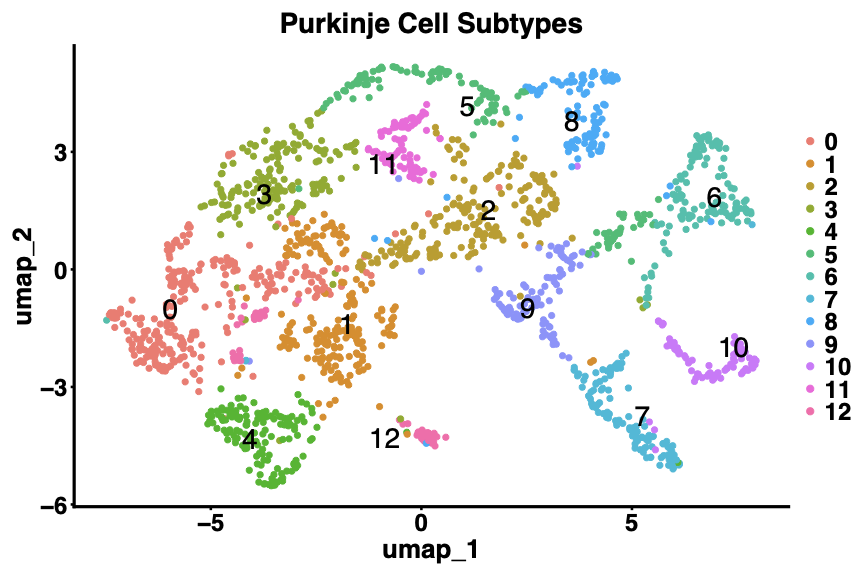

Purkinje cell subtypes UMAP

**Result**: Identified 13 PC subtypes (vs 11 in published study)

## 6.4 Subtype Marker Analysis

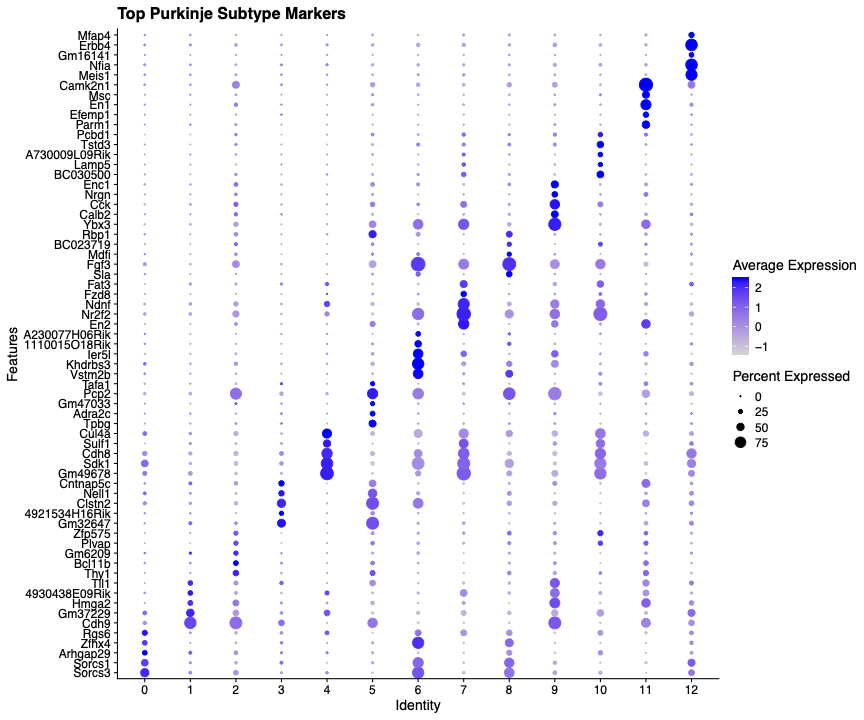

Top markers for each PC subtype

**Representative markers identified**:

# 7 Differential Expression Analysis

## 7.1 Rationale

To identify genes and pathways associated with Purkinje cell maturation, we compared mature PCs between E16.5 and E18.5.

**Subset analyzed**: Mature PC only (excluded PC.immature to focus on maturation-associated changes)

## 7.2 Methods

```r
# Subset to mature PC
mature_pc <- subset(obj, cell_type == "PC")

# Differential expression: E18.5 vs E16.5
Idents(mature_pc) <- "stage"
de_genes <- FindMarkers(mature_pc,
                        ident.1 = "E18.5",
                        ident.2 = "E16.5",
                        min.pct = 0.10,
                        logfc.threshold = 0.25,
                        test.use = "wilcox")
```

## 7.3 Volcano Plot

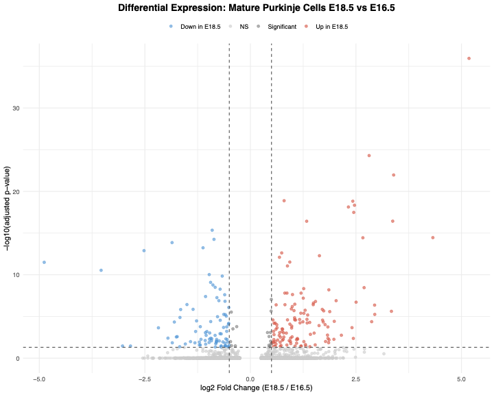

Volcano plot of DE genes

## 7.4 Results Summary

- **Upregulated at E18.5**: 182 genes
- **Downregulated at E18.5**: 49 genes

**Top upregulated genes** (E18.5 > E16.5):

- Oxidative phosphorylation: Cox6a2, Cox7a1, Uqcrh, Atp5g1
- Ribosomal proteins: Rpl13, Rps15, Rpl36, Rps27
- Synaptic: Gria3, Grin2c, Kcnj10

**Top downregulated genes** (E18.5 < E16.5):

- Developmental: Mdk, Nrp1, Sema3e
- Cell adhesion: Nrcam, Cdh2

# 8 GO and Pathway Enrichment Analysis

## 8.1 Gene Ontology Analysis

### 8.1.1 Biological Process

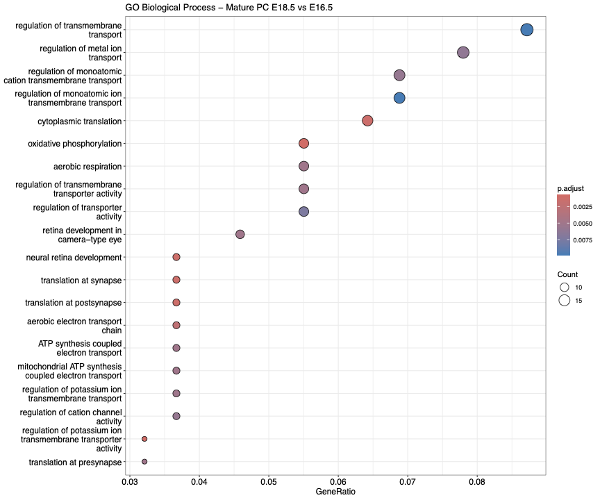

GO Biological Process enrichment

### 8.1.2 Cellular Component

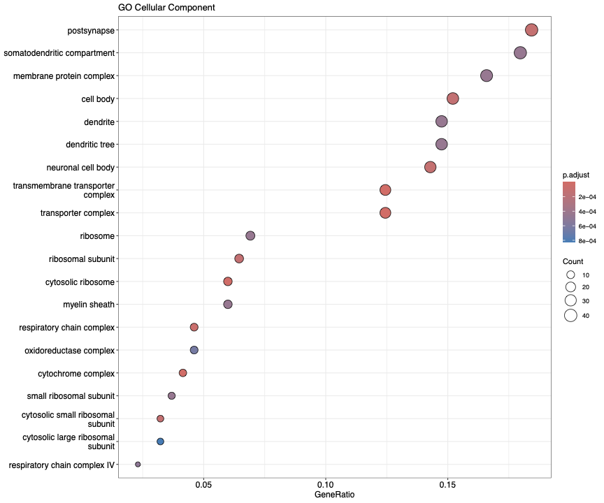

GO Cellular Component enrichment

**Key subcellular localizations**:

1. Synaptic compartments: Postsynapse, dendritic tree
2. Ribosomes: Cytosolic ribosomes
3. Mitochondria: Respiratory chain complexes
4. Neuronal structure: Cell body, dendrites

### 8.1.3 Molecular Function

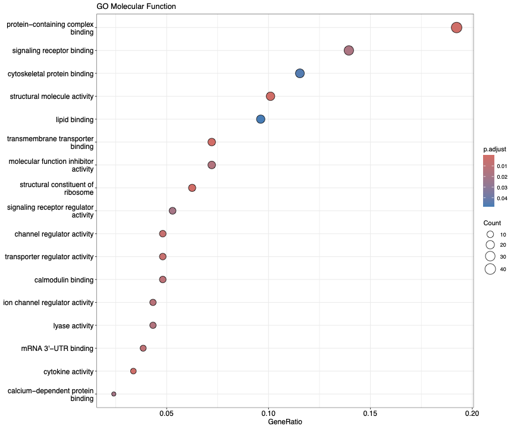

GO Molecular Function enrichment

**Key molecular activities**:

1. Structural constituent of ribosome
2. Channel/transporter regulator activity
3. Protein complex binding
4. Calmodulin binding

## 8.2 KEGG Pathway Analysis

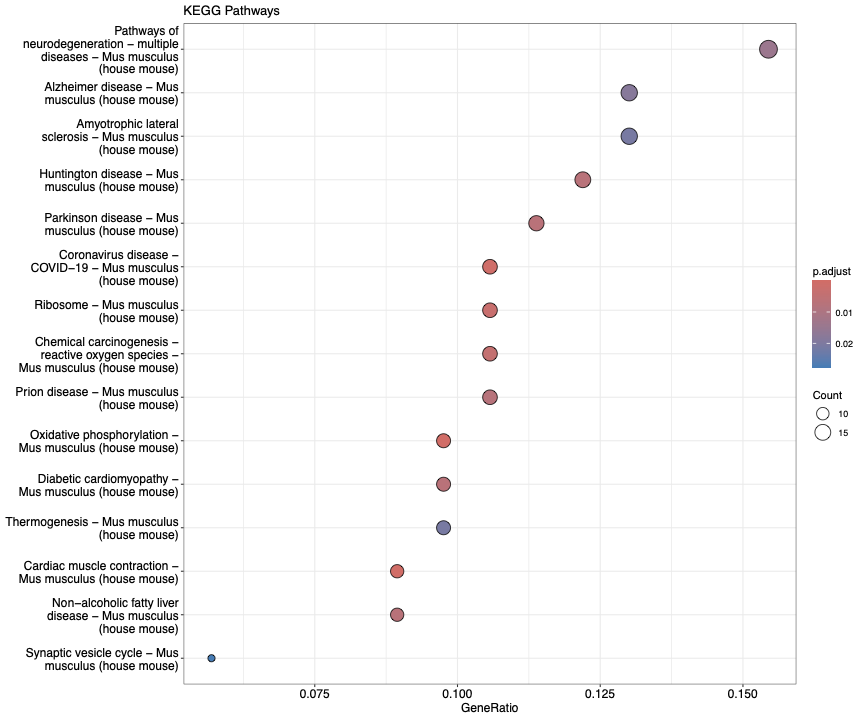

KEGG pathway enrichment

**Top pathways**:

1. Oxidative phosphorylation
2. Ribosome
3. Synaptic vesicle cycle
4. Neurodegeneration pathways (Alzheimer’s, Parkinson’s, Huntington’s)

## 8.3 GSEA Results

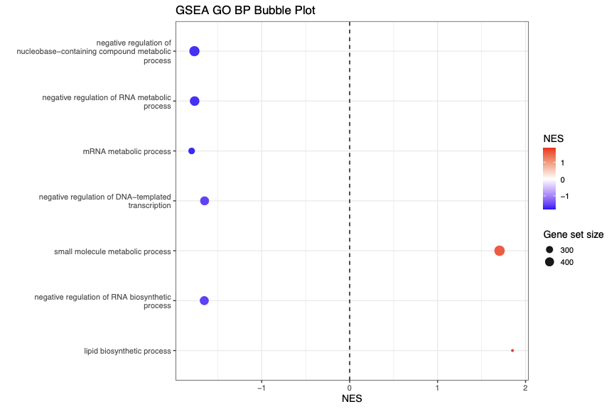

GSEA GO BP bubble plot

# 9 Cell-Cell Communication Analysis

## 9.1 Rationale

Cerebellar development from E16.5 to E18.5 represents a critical transition period characterized by active neuronal maturation, gliogenesis, and circuit assembly. To understand how intercellular signaling networks evolve during this developmental window, we performed systematic cell-cell communication analysis using CellChat.

**Biological context**: At E16.5-E18.5, Purkinje cells are forming the Purkinje cell layer and beginning dendritic development. During this period, they communicate with neighboring cells including Bergmann glia and granule cell precursors to coordinate proper cerebellar development.

## 9.2 Methods

```r
library(CellChat)

# Create CellChat objects for each stage
e16_data <- GetAssayData(subset(obj, stage == "E16.5"), layer = "data")
e18_data <- GetAssayData(subset(obj, stage == "E18.5"), layer = "data")

cellchat_e16 <- createCellChat(object = e16_data,
                               meta = subset(obj, stage == "E16.5")@meta.data,
                               group.by = "cell_type")

cellchat_e18 <- createCellChat(object = e18_data,
                               meta = subset(obj, stage == "E18.5")@meta.data,
                               group.by = "cell_type")

# Load ligand-receptor database
cellchat_e16@DB <- CellChatDB.mouse
cellchat_e18@DB <- CellChatDB.mouse

# Preprocessing and inference
cellchat_e16 <- subsetData(cellchat_e16)
cellchat_e16 <- identifyOverExpressedGenes(cellchat_e16)
cellchat_e16 <- identifyOverExpressedInteractions(cellchat_e16)
cellchat_e16 <- computeCommunProb(cellchat_e16, type = "triMean")
cellchat_e16 <- filterCommunication(cellchat_e16, min.cells = 10)
cellchat_e16 <- computeCommunProbPathway(cellchat_e16)
cellchat_e16 <- aggregateNet(cellchat_e16)
cellchat_e16 <- netAnalysis_computeCentrality(cellchat_e16)

# Same for E18.5
cellchat_e18 <- subsetData(cellchat_e18)
cellchat_e18 <- identifyOverExpressedGenes(cellchat_e18)
cellchat_e18 <- identifyOverExpressedInteractions(cellchat_e18)
cellchat_e18 <- computeCommunProb(cellchat_e18, type = "triMean")
cellchat_e18 <- filterCommunication(cellchat_e18, min.cells = 5)
cellchat_e18 <- computeCommunProbPathway(cellchat_e18)
cellchat_e18 <- aggregateNet(cellchat_e18)
cellchat_e18 <- netAnalysis_computeCentrality(cellchat_e18)
```

**Key parameters**:

- **Database**: CellChatDB.mouse (curated ligand-receptor interactions)
- **Probability calculation**: triMean
- **Filtering**: min.cells = 10 (E16.5), min.cells = 5 (E18.5, accounting for fewer cells)
- **Cell types analyzed**: All 19 cerebellar cell types
- **Focus**: 7 key neural cell types (PC, PC.immature, BG, GC, GCP, GABA.diff, IN)

## 9.3 Overall Communication Dynamics

### 9.3.1 Stage Comparison

**Plot description**: Bar plots comparing total intercellular communication between E16.5 and E18.5. Left panel shows the number of significant cell-cell interactions detected. Right panel shows the total interaction strength (sum of communication probabilities). Both metrics show substantial decrease from E16.5 to E18.5.

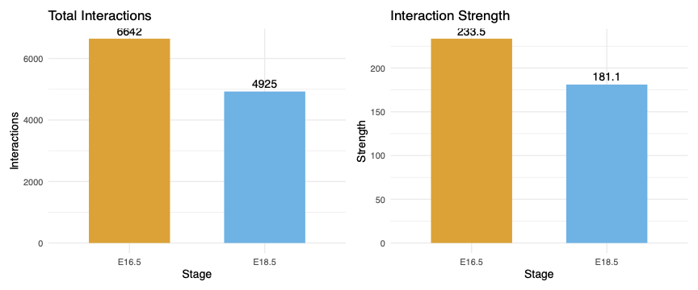

Overall communication comparison

**Key finding**: Communication decreased by **25.9%** from E16.5 to E18.5

- E16.5: 6,642 interactions, strength 233.5
- E18.5: 4,925 interactions, strength 181.1

**Biological interpretation**: The decrease in cell-cell communication suggests developmental maturation and cellular specialization. At E16.5, cells seem to be actively establishing their identities and require extensive intercellular signaling. By E18.5, cells more committed to their fates and communication becoming more refined and selective

### 9.3.2 Communication Hubs

**Plot description**: Heatmaps showing the number of interactions between all cerebellar cell types. The central heatmap shows cell-cell interaction counts (darker = more interactions). Marginal bar plots show the total incoming signals (top bars, how much each cell type receives) and outgoing signals (right bars, how much each cell type sends). These identify major signaling “hubs” in the network.

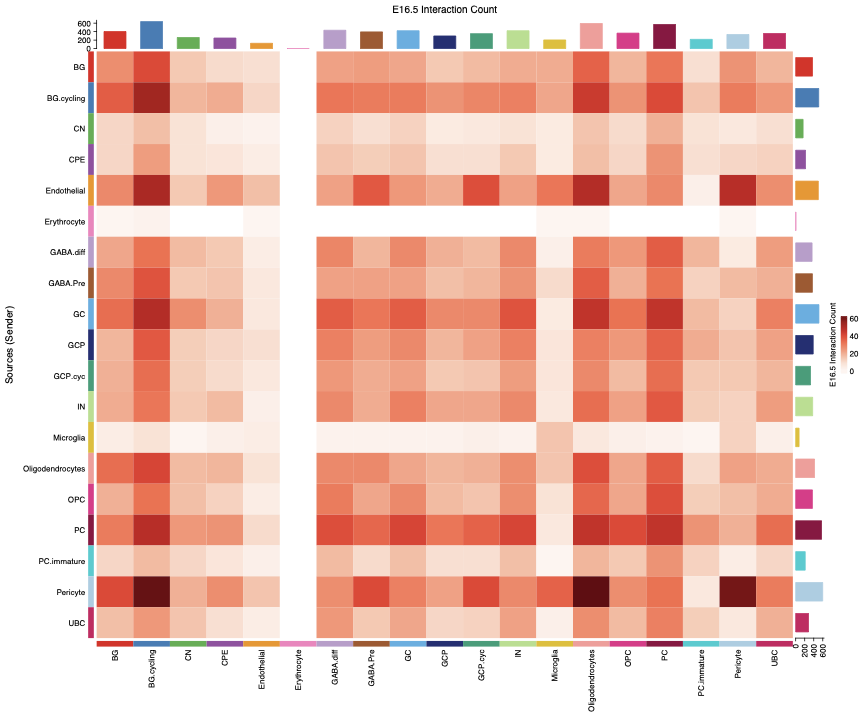

E16.5 signaling hubs

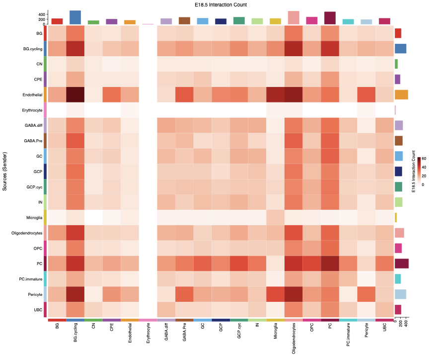

E18.5 signaling hubs

**E18.5 changes**:

- Overall reduction in bar heights (consistent with 26% decrease)
- GCP signaling reduced (proliferative phase waning)
- Maintained communication: Bergmann glia ↔︎ Purkinje cells

### 9.3.3 Network Visualization

**Plot description**: Chord diagrams showing the communication network structure for 7 key neural cell types. Each arc represents a cell type (color-coded). Curved bands connecting arcs represent directional signaling from sender to receiver. Band thickness indicates interaction strength (thicker = more communication). In our plots, both stages show similar network topology, reflecting that the same cell-cell communication pathways are active at both stages

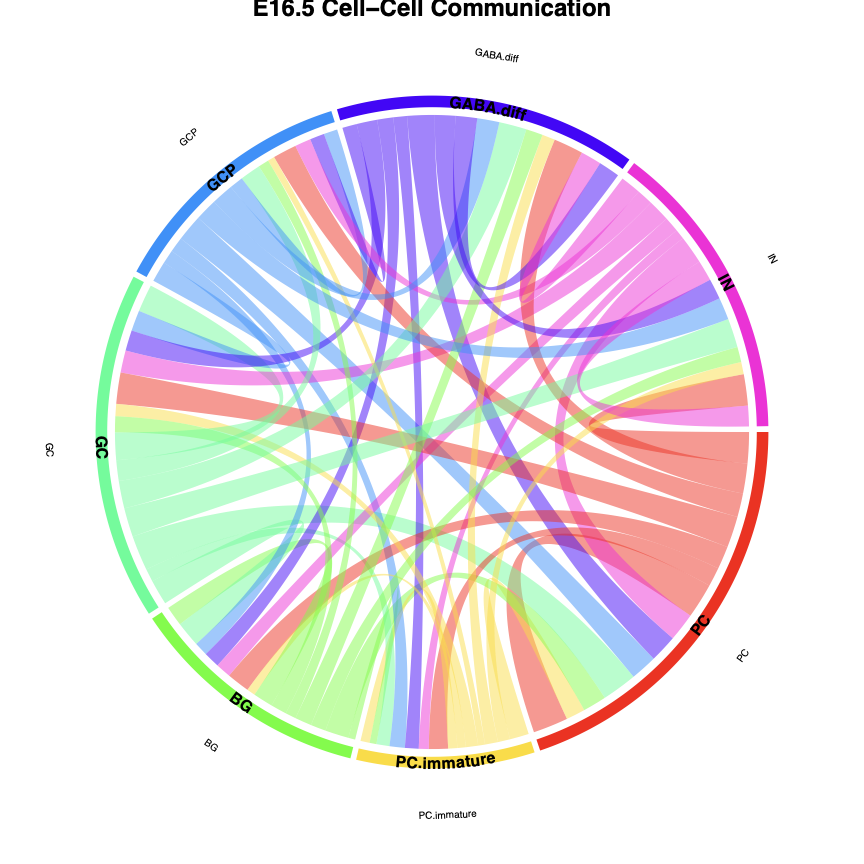

E16.5 communication network

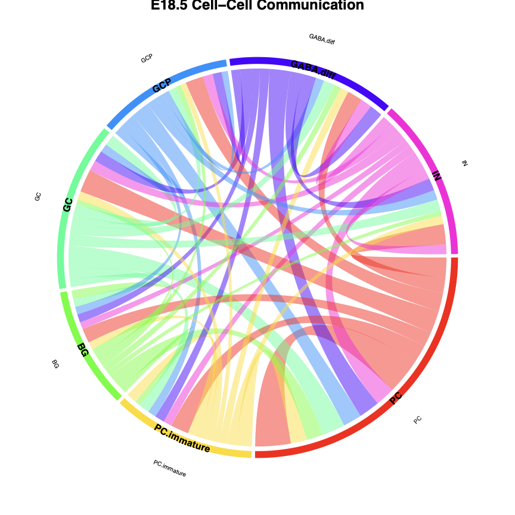

E18.5 communication network

**Plot description**: Bar plot showing the top 10 cell types that send signals TO Purkinje cells (PC + PC.immature combined). Bars are grouped by developmental stage (E16.5 in orange, E18.5 in blue) to enable direct comparison. Y-axis shows the total number of incoming interactions from each source cell type.

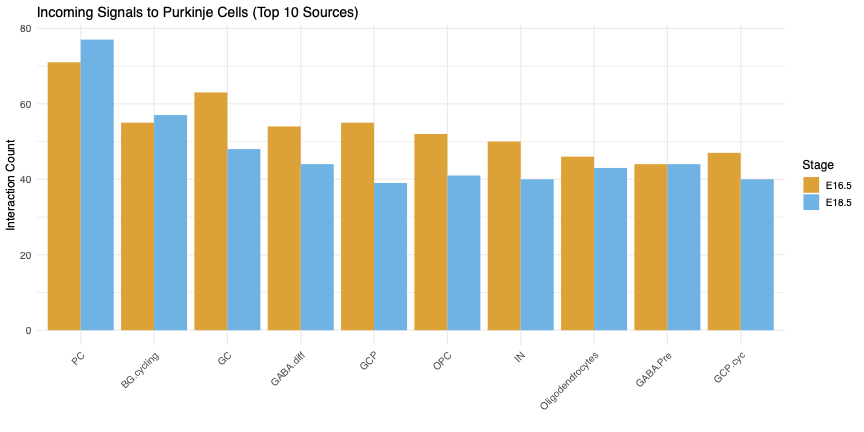

Incoming signals to Purkinje cells

**Top sources of signals TO Purkinje** (E16.5 → E18.5 change):

1. **PC → PC** (71 → 77, +6): Purkinje self-signaling **INCREASED**
2. **GC → PC** (63 → 48, -15, -24%): Granule cells reduced
3. **GCP → PC** (55 → 39, -16, -29%): Granule precursors **largest decrease**
4. **GABA.diff → PC** (54 → 44, -10): GABAergic neurons reduced
5. **IN → PC** (50 → 40, -10): Interneurons reduced

### 9.3.4 Outgoing Signals from Purkinje Cells

**Plot description**: Bar plot showing the top 10 cell types that RECEIVE signals FROM Purkinje cells. Same layout as incoming signals plot—grouped bars allow stage comparison. Y-axis shows total outgoing interactions to each target cell type.

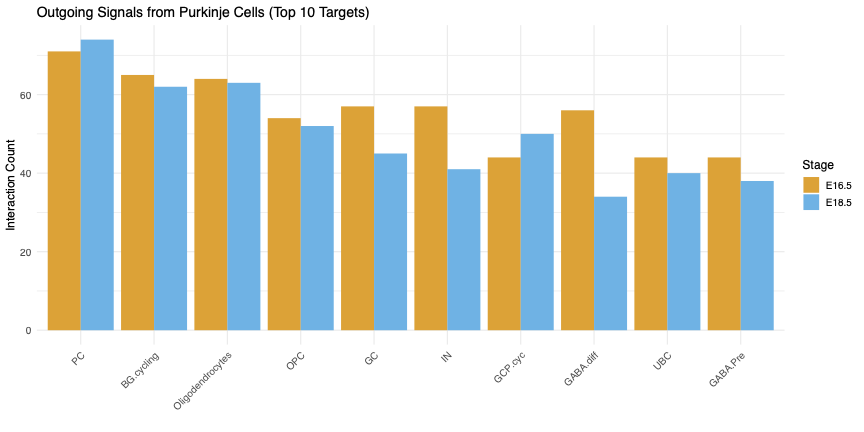

Outgoing signals from Purkinje cells

### 9.3.5 Pathway Bubble Plots

These plots allow identification of which specific molecular interactions drive the pathway-level changes observed above.

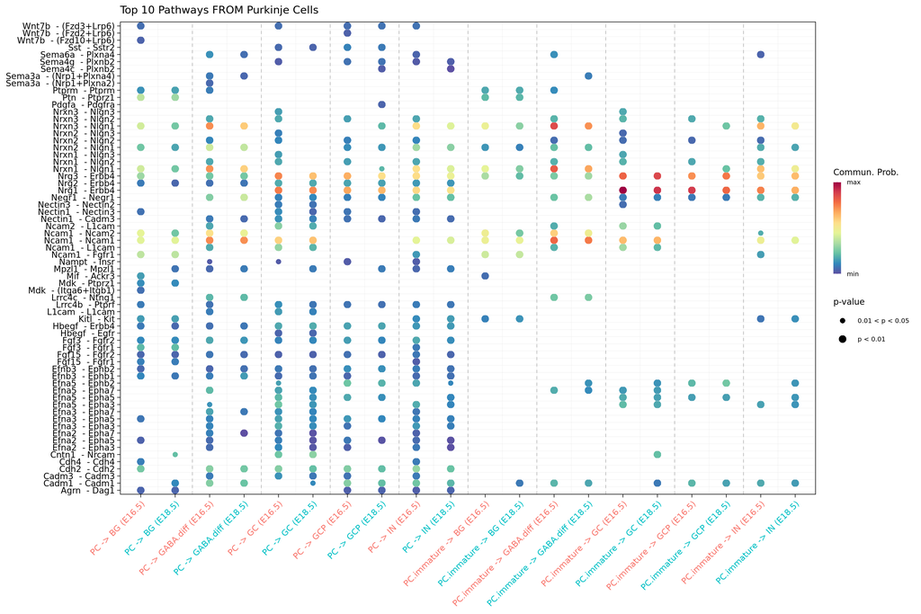

Pathways FROM Purkinje to partners

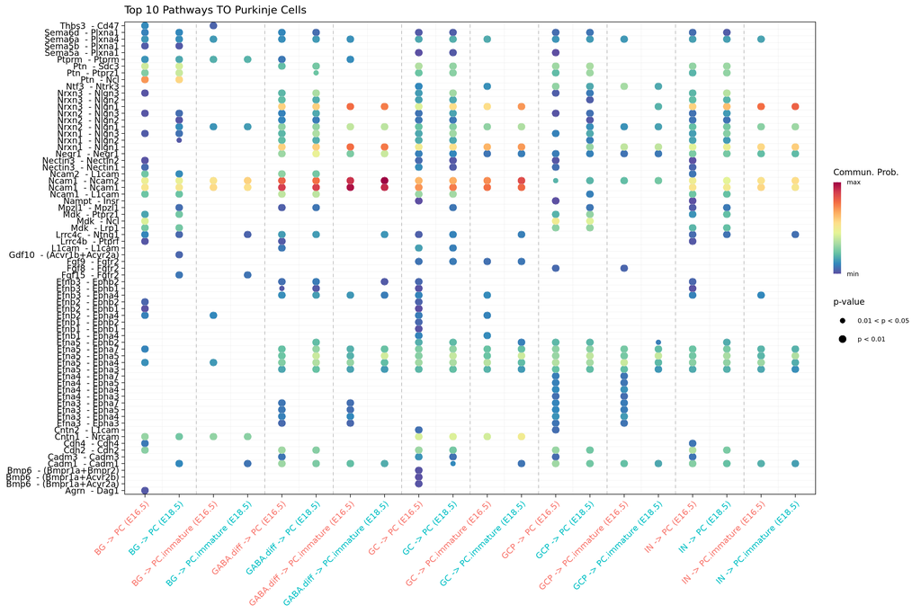

Pathways TO Purkinje from partners

**Notable ligand-receptor pairs**:

**FROM Purkinje**:

- **Nrg1-Erbb4**: Purkinje → Bergmann glia (supports glial differentiation)
- **Nrxn1/2/3 - Nlgn1/2/3**: Purkinje → multiple targets (synaptic organization)
- **Efnb1/2/3 - Ephb1/2**: Purkinje → GC, IN (dendritic spine formation)

**TO Purkinje**:

- **Ncam1-Ncam1**: Homophilic adhesion from multiple sources
- **Efna2/3/4/5 - Epha3/4/5/7**: EphrinA signaling from GC, GCP, IN (axon guidance)
- **Cntn1/2 - Nrcam/L1cam**: Contactin-based adhesion (neurite outgrowth)

# 10 Comparison to Published Results

## 10.1 Similarities with Khouri-Farah et al. (2025)

- **Number of subtypes**: We identified 13 PC subtypes vs 11 in the paper (difference likely due to resolution parameter and clustering algorithm)
- **Foxp2 as pan-PC marker**: Confirmed across all subtypes
- **Cadherin expression**: Both studies identify cell adhesion molecules as key subtype markers
- **“Subtle and gradual” maturation**: Paper states differentiation is subtle at E16.5-E18.5, our findings support this

## 10.2 Key Differences

- **Maturation state**: We separated mature vs immature PCs, revealing maturation-specific gene expression programs
- **Sample composition**: Our E18.5 sample shows unexpected immature PC enrichment, likely reflecting regional sampling variation
- **Communication dynamics**: The CellChat analysis is not explored in the original paper, revealing the intercellular signaling landscape during this developmental window

# 11 Discussion

## 11.2 Technical Considerations

### 11.2.1 Sample Size Limitations

**Replicates**: E18.5 has only **1 biological replicate** vs 2 for E16.5

**Impact**:

- Limits statistical power for stage comparisons
- Cannot perform pseudobulk DESeq2 (requires ≥2 replicates/condition)

**Mitigation**: Focused analysis on mature PC only. CellChat analysis uses all cells within each stage, providing statistical power despite single replicate

### 11.2.2 Sampling Variation

# 12 Conclusions

This analysis provides a comprehensive characterization of Purkinje cell development during late embryonic mouse cerebellar development. We identified 13 molecularly distinct PC subtypes and revealed a coordinated maturation program involving metabolic switching, synaptic preparation, ion channel regulation, and communication network refinement.

# 13 Methods Summary

## 13.1 Software and Versions

- **SRA Toolkit**: v3.0.1
- **Cell Ranger**: v9.0.1
- **R**: v4.4.0
- **Seurat**: v5.2.1
- **Harmony**: v1.2.0
- **clusterProfiler**: v4.14.0
- **CellChat**: v2.1.2

## 13.2 Key Parameters

**Integration**:

- Method: Harmony
- Dimensions: 1-30

**Clustering**:

- Algorithm: Louvain
- Resolution: 0.5 (whole dataset), 1.2 (Purkinje subset)

**Differential Expression**:

- Test: Wilcoxon rank-sum
- logfc.threshold: 0.25
- min.pct: 0.10

**GO/GSEA**:

- Organism: org.Mm.eg.db
- P-adjustment: Benjamini-Hochberg
- Cutoff: padj < 0.05

**CellChat**:

- Database: CellChatDB.mouse
- Probability method: triMean
- Min cells: 10 (E16.5), 5 (E18.5)

# 14 Data Availability

**Raw data**: GEO accession GSE256438

**Processed data**: Available upon request

# 15 References

1. Khouri-Farah N, et al. (2025) FOXP genes regulate Purkinje cell diversity and cerebellar morphogenesis. *Nature Neuroscience*.
2. Hao Y, et al. (2024) Dictionary learning for integrative, multimodal and scalable single-cell analysis. *Nature Biotechnology*.
3. Korsunsky I, et al. (2019) Fast, sensitive and accurate integration of single-cell data with Harmony. *Nature Methods*.
4. Yu G. (2024) Thirteen years of clusterProfiler. *The Innovation*.
5. Jin S, et al. (2021) Inference and analysis of cell-cell communication using CellChat. *Nature Communications* 12, 1088.
6. Millen, K. J. (2025) Essential new insights into human cerebellar Purkinje cell biology from studies of essential tremor. Proc. Natl. Acad. Sci. U.S.A. 122, e2514663122.

Generative AI tools were used for code review and troubleshooting assistance during development of the analysis pipeline.